# Bush_v_Gore_2000

Theo Killian

November 7, 2019

# Introduction

This report performs a textual analysis of the infamous [Bush v. Gore 2000](https://www.law.cornell.edu/supct/html/00-949.ZPC.html) opinion. This opinion was written by an anonymous US Supreme Court Justice, likely by one of the 5 conservative Supreme Court justices serving on the court at that time: O’Connor, Rehnquist, Thomas, Kennedy and Scalia. In this analysis, we utilize a number of NLP techniques, such as hierarchical clustering, bootstrap consensus trees, characteristic vocabulary, and other methods. We have sampled the opinions written by each of the five conservative justices between the period 1999-2001 for comparison to the [Bush v. Gore 2000](https://www.law.cornell.edu/supct/html/00-949.ZPC.html) opinion, in order to ascertain the probable author of this document.

```r
library("readtext")
library("quanteda")
library("dplyr")
library("readtext")
library("ggplot2")
library("tm")
library("gridExtra")
# library("xgboost")
# library("fortunes")
# library("tm")
# library("e1071")
# library("mlr")
set.seed(132)
```

### Load Data

The Bush v. Gore opinion is read into R as a single `readtext` object. We will also compile the opinions written by each of the five conservative justices between the period 1999-2001 (+/- 1 year from when the anonymous SC opinion was written in 2000). Each body of documents from each justice can be read a single `readtext` ‘glob’ where each single document can be individually selected or evaluated together a single object.

```r
opinion <- readtext("./opinions/Bush_v_Gore.txt")

KENNEDY <- system.file("./opinions/Kennedy/", package = "readtext")
kennedy <- readtext(paste0(KENNEDY, "./opinions/Kennedy/*"))

OCONNOR <- system.file("./opinions/OConnor/", package = "readtext")
oconnor <- readtext(paste0(OCONNOR, "./opinions/OConnor/*"))

REHNQUIST <- system.file("./opinions/Rehnquist/", package = "readtext")
rehnquist <- readtext(paste0(REHNQUIST, "./opinions/Rehnquist/*"))

SCALIA <- system.file("./opinions/Scalia/", package = "readtext")
scalia <- readtext(paste0(SCALIA, "./opinions/Scalia/*"))

THOMAS <- system.file("./opinions/Thomas/", package = "readtext")
thomas <- readtext(paste0(THOMAS, "./opinions/Thomas/*"))
```

### Corpus Generation

[Corpuses](https://tutorials.quanteda.io/basic-operations/corpus/corpus/) for each SC justice are generated using the `quanteda` R package. A corpus is a data frame consisting of a character vector for each documents. The summary of each corpus lists the statistics on `Types,` `Tokens` and `Sentences` for each document.

```r
opinion_corpus <- corpus(opinion)
kennedy_corpus <- corpus(kennedy)
oconnor_corpus <- corpus(oconnor)
rehnquist_corpus <- corpus(rehnquist)
scalia_corpus <- corpus(scalia)
thomas_corpus <- corpus(thomas)

# summary(opinion_corpus)
# Corpus consisting of 1 document:
#
#             Text Types Tokens Sentences
#  Bush_v_Gore.txt  1066   4049       168
# summary(kennedy_corpus)
# Corpus consisting of 25 documents:
#
#                                                                      Text Types Tokens Sentences
#               01 - City of Monterey v Del Monte Dunes at Monterey Ltd.txt  2224  12227       578
#                                                      02 - Glover v US.txt   732   2444       120
#                                    03 - City of West Covina v Perkins.txt   907   3271       159
#                                            04 - INS v Aguirre-Aguirre.txt  1303   6408       309
#                                           05 - US v Haggar Apparel Co.txt  1155   4846       211
#                                                     06 - Peguero v US.txt   650   2536       118
#                                                     07 - US v Johnson.txt   732   2642       113
#                     08 - TrafFix Devices Inc v Marketing Displays Inc.txt  1026   4269       190
#                                            09 - US v United Foods Inc.txt  1087   4020       210
#                                                       10 - US v Locke.txt  1975   9406       447
#                                                     11 - Fischer v US.txt  1208   4985       200
#                                                    12 - Mitchell v US.txt  1388   5827       275
#                                  13 - Legal Services Corp v Velazquez.txt  1306   5165       242
#                                                   14 - Saucier v Katz.txt  1195   5055       227
#  15 - Board of Regents of University of Wisconsin System v Southworth.txt  1469   5984       305
#                                                  16 - Rice v Cayetano.txt  2306  10397       530
#                                                   17 - Garner v Jones.txt  1079   4593       236
#                                            18 - Tuan Anh Nguyen v INS.txt  1465   7039       284
#                                  19 - Circuit City Stores Inc v Adams.txt  1417   6384       268
#                                                 20 - Slack v McDaniel.txt   989   5090       245
#                             21 - US v Playboy Entertainment Group Inc.txt  1903   8539       417
#                  22 - Amoco Production Co v Southern Ute Indian Tribe.txt  1337   5242       234
#                                                23 - Williams v Taylor.txt  1715   8725       388
#                                         24 - Palazzolo v Rhode Island.txt  1919   8602       401
#                                                    25 - Alden v Maine.txt  2933  20241       886
# summary(oconnor_corpus)
# Corpus consisting of 26 documents:
#
#                                                              Text Types Tokens Sentences
#                   01 - Lackawanna County Dist Attorney v Coss.txt  1054   5039       273
#                                             02 - Daniels v US.txt   925   3661       186
#                       04 - Murphy v United Parcel Service Inc.txt   683   2693       106
#                              05 - US Postal Service v Gregory.txt   808   2938       167
#                            06 - City of Indianapolis v Edmond.txt  1381   5748       324
#                                           07 - Martin v Hadix.txt  1156   6341       278
#                                           08 - Seling v Young.txt  1268   5845       323
#                        09 - Norfolk Southern Ry Co v Shanklin.txt  1036   5346       233
#                                          10 - Penry v Johnson.txt  1361   7539       360
#                          11 - Kolstad v American Dental Ass'n.txt  1610   7441       326
#                            12 - Sutton v United Air Lines Inc.txt  1538   7735       293
#                                          13 - Miller v French.txt  1660   8982       394
#                 14 - Reeves v Sanderson Plumbing Products Inc.txt  1626   7540       366
#                                  15 - Lopez v Monterey County.txt  1476   7782       369
#                       16 - Lewis v Lewis And Clark Marine Inc.txt  1314   6730       369
#                                          17 - Duncan v Walker.txt  1090   5331       233
#                                      18 - Roe v Flores-Ortega.txt  1223   6069       252
#                                  19 - City of Erie v Pap's AM.txt  1698   8116       391
#                                    20 - O'Sullivan v Boerckel.txt   923   3936       205
#                                       21 - Rogers v Tennessee.txt  1345   5969       264
#  22 - Davis Next Friend LaShonda D v Monroe County Bd of Educ.txt  1786   9099       389
#                            23 - Kimel v Florida Bd of Regents.txt  2089  12134       638
#  24 - Food and Drug Admin v Brown And Williamson Tobacco Corp.txt  2456  15412       695
#     25 - Department of Commerce v US House of Representatives.txt  2026  10140       466
#                            26 - Lorillard Tobacco Co v Reilly.txt  2525  15546       840
#          27 - Minnesota v Mille Lacs Band of Chippewa Indians.txt  2133  13684       702
# summary(rehnquist_corpus)
# Corpus consisting of 26 documents:
#
#                                                                                  Text Types Tokens Sentences
#                                            01 - Department of Army v Blue Fox Inc.txt   938   3685       157
#                                                               02 - Conn v Gabbert.txt   743   2443       124
#                                                                    03 - Bond v US.txt   570   1583        81
#                                          04 - Lujan v G And G Fire Sprinklers Inc.txt   885   3573       182
#                                     05 - Buckman Co v Plaintiffs' Legal Committee.txt  1165   4146       142
#                                                           06 - Illinois v Wardlow.txt   713   2201       138
#                                                                07 - Reno v Condon.txt   905   3424       150
#                                                                 08 - US v Knights.txt   989   3408       168
#                          09 - Los Angeles Police Dept v United Reporting Pub Corp.txt   931   3312       153
#                                                                   10 - Ohler v US.txt   644   2375       104
#                                                               11 - Wilson v Layne.txt  1383   5477       284
#                                                             12 - Florida v Thomas.txt   668   2263       128
#                                         13 - Correctional Services Corp v Malesko.txt  1251   5150       269
#                                                                 14 - Texas v Cobb.txt  1120   4040       197
#                                            15 - Atkinson Trading Co Inc v Shirley.txt  1257   5569       251
#                                                             16 - Weeks v Angelone.txt  1042   4411       208
#  17 - Buckhannon Bd and Care Home Inc v West Virginia Dept of Health and Human Re.txt  1261   5299       258
#                                                                   18 - Neder v US.txt  1741   9683       432
#                                                               19 - Dickerson v US.txt  1520   6537       391
#                                                 20 - Boy Scouts of America v Dale.txt  1552   6898       314
#      21 - Solid Waste Agency of Northern Cook County v US Army Corps of Engineers.txt  1317   5454       235
#                                          22 - American Mfrs Mut Ins Co v Sullivan.txt  1536   7869       364
#                                 23 - Green Tree Financial Corp-Alabama v Randolph.txt  1124   4735       211
#             24 - Florida Prepaid Postsecondary Educ Expense Bd v College Sav Bank.txt  1632   7958       354
#                         25 - Board of Trustees of University of Alabama v Garrett.txt  1582   6329       307
#                                                                26 - US v Morrison.txt  2264  11670       583
# summary(scalia_corpus)
# Corpus consisting of 24 documents:
#
#                                                                       Text Types Tokens Sentences
#                                                   01 - Artuz v Bennett.txt   716   2479        92
#                   02 - Your Home Visiting Nurse Services Inc v Shalala.txt   776   3022       120
#                                                   03 - New York v Hill.txt  1014   3518       195
#                             05 - Wal-Mart Stores Inc v Samara Bros Inc.txt   989   3886       126
#             06 - Hartford Underwriters Ins Co v Union Planters Bank NA.txt  1253   5098       219
#                    07 - Norfolk Shipbuilding And Drydock Corp v Garris.txt  1043   3889       214
#                          08 - NLRB v Kentucky River Community Care Inc.txt  1347   6317       275
#                                                        09 - Kyllo v US.txt  1319   4975       214
#                                                 10 - Portuondo v Agard.txt  1448   5824       291
#                          11 - Semtek Intern Inc v Lockheed Martin Corp.txt  1162   4789       206
#                                               12 - Edwards v Carpenter.txt   684   2393       100
#          13 - Grupo Mexicano de Desarrollo SA v Alliance Bond Fund Inc.txt  1741   7581       312
#                            14 - US v Sun-Diamond Growers of California.txt  1278   5851       154
#                          15 - Whitman v American Trucking Associations.txt  2048  10802       474
#                                                16 - Wyoming v Houghton.txt  1115   4180       184
#          17 - Grupo Mexicano de Desarrollo SA v Alliance Bond Fund Inc.txt  2027   9696       436
#  18 - College Sav Bank v Florida Prepaid Postsecondary Educ Expense Bd.txt  2140  10115       478
#           19 - Vermont Agency of Natural Resources v US ex rel Stevens.txt  2184  10465       491
#                                   20 - Reno v Bossier Parish School Bd.txt  1574   8149       310
#                                              21 - Alexander v Sandoval.txt  1608   7920       405
#                               22 - California Democratic Party v Jones.txt  1671   7563       342
#                23 - Reno v American-Arab Anti-Discrimination Committee.txt  1753   8384       278
#                                 24 - AT And T Corp v Iowa Utilities Bd.txt  1831  10220       339
#                                                    25 - Nevada v Hicks.txt  1713   8295       359
# summary(thomas_corpus)
# Corpus consisting of 23 documents:
#
#                                                           Text Types Tokens Sentences
#                                            01 - Jones v US.txt  2044  12766       606
#          02 - Arizona Dept of Revenue v Blaze Const Co Inc.txt   739   2335       140
#                                         03 - Shaw v Murphy.txt   903   3093       173
#                                       04 - Florida v White.txt   705   2479       125
#                                 05 - US v Rodriguez-Moreno.txt   705   2778       114
#          06 - Director of Revenue of Missouri v CoBank ACB.txt   670   2936       116
#                07 - Pollard v EI du Pont de Nemours And Co.txt   931   3987       158
#                     08 - Cunningham v Hamilton County Ohio.txt  1243   4789       264
#                                          09 - Sims v Apfel.txt   976   3587       200
```

```r
#                   10 - US v Oakland Cannabis Buyers' Co-op.txt  1250   5728       257
#                                         11 - Beck v Prupis.txt  1211   5736       218
#                                            12 - Baral v US.txt   742   3448       106
#                    13 - Egelhoff v Egelhoff ex rel Breiner.txt  1053   3975       199
#                                      14 - Hunt v Cromartie.txt  1245   5068       256
#                                         15 - Gitlitz v CIR.txt   861   5312       185
#        16 - JEM Ag Supply Inc v Pioneer Hi-Bred Intern Inc.txt  1554   7794       366
#                                           17 - Carter v US.txt  1501   7479       323
#                                          18 - Tyler v Cain.txt  1000   4926       240
#                           19 - Christensen v Harris County.txt  1056   4602       197
#                         20 - Hughes Aircraft Co v Jacobson.txt  1240   5632       248
#  21 - Harris Trust and Sav Bank v Salomon Smith Barney Inc.txt  1215   6284       200
#               22 - Good News Club v Milford Central School.txt  1555   7730       364
#                                       23 - Smith v Robbins.txt  1953  11778       518
```

### Data Cleaning

We will need to convert the text to lower case and remove any non-ASCII characters so that the texts can be compared for later analysis. The corpuses will be tokenized, English stop words (such as “the”, “and” etc.) removed and the corpuses converted to document feature matrices (DFMs).

```r
## convert the corpus to all lower case
opinion_lower <- tolower(opinion_corpus)
kennedy_lower <- tolower(kennedy_corpus)
oconnor_lower <- tolower(oconnor_corpus)
rehnquist_lower <- tolower(rehnquist_corpus)
scalia_lower <- tolower(scalia_corpus)
thomas_lower <- tolower(thomas_corpus)

## convert the coprpus into tokens
opinion_tokes <- tokens(opinion_lower)
kennedy_tokes <- tokens(kennedy_lower)
oconnor_tokes <- tokens(oconnor_lower)
rehnquist_tokes <- tokens(rehnquist_lower)
scalia_tokes <- tokens(scalia_lower)
thomas_tokes <- tokens(thomas_lower)

## remove stop words from corpus
opinion_nostop <- tokens_select(opinion_tokes, pattern = stopwords('en'),
                                selection = 'remove')
kennedy_nostop <- tokens_select(kennedy_tokes, pattern = stopwords('en'),
                                selection = 'remove')
oconnor_nostop <- tokens_select(oconnor_tokes, pattern = stopwords('en'),
                                selection = 'remove')
rehnquist_nostop <- tokens_select(rehnquist_tokes, pattern = stopwords('en'),
                                selection = 'remove')
scalia_nostop <- tokens_select(scalia_tokes, pattern = stopwords('en'),
                                selection = 'remove')
thomas_nostop <- tokens_select(thomas_tokes, pattern = stopwords('en'),
                                selection = 'remove')

## remove numbers and punctuation from corpus
opinion_cleaned <- tokens_remove(tokens(opinion_nostop, remove_punct = TRUE,
                                 remove_numbers = TRUE), stopwords("english"))
kennedy_cleaned <- tokens_remove(tokens(kennedy_nostop, remove_punct = TRUE,
                                 remove_numbers = TRUE), stopwords("english"))
oconnor_cleaned <- tokens_remove(tokens(oconnor_nostop, remove_punct = TRUE,
                                 remove_numbers = TRUE), stopwords("english"))
rehnquist_cleaned <- tokens_remove(tokens(rehnquist_nostop, remove_punct = TRUE,
                                   remove_numbers = TRUE), stopwords("english"))
scalia_cleaned <- tokens_remove(tokens(scalia_nostop, remove_punct = TRUE,
                                 remove_numbers = TRUE), stopwords("english"))
thomas_cleaned <- tokens_remove(tokens(thomas_nostop, remove_punct = TRUE,
                                remove_numbers = TRUE), stopwords("english"))

## Create the corpus dfm
opinion_dfm <- dfm(opinion_cleaned)
kennedy_dfm <- dfm(kennedy_cleaned)
oconnor_dfm <- dfm(oconnor_cleaned)
rehnquist_dfm <- dfm(rehnquist_cleaned)
scalia_dfm <- dfm(scalia_cleaned)
thomas_dfm <- dfm(thomas_cleaned)
```

### Top Features

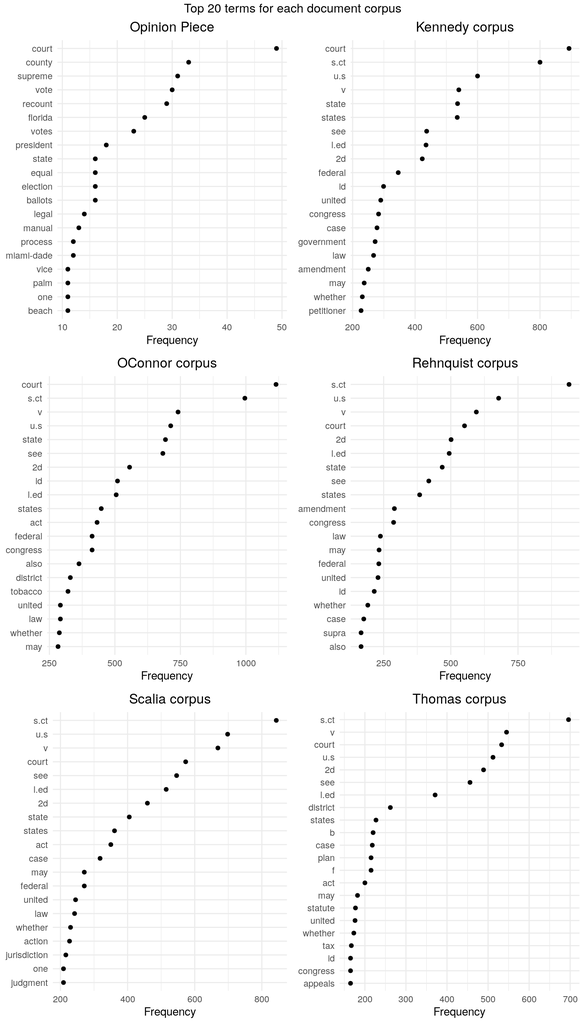

```r
p1 <- textstat_frequency(opinion_dfm) %>%
                dplyr::select(feature, frequency) %>%
                top_n(20) %>%
                ggplot(aes(x = reorder(feature, frequency), y = frequency)) +
                geom_point() +
                coord_flip() +
                labs(x = NULL, y = "Frequency") +
                theme_minimal() +
                ggtitle("Opinion Piece") +
                theme(plot.title = element_text(hjust = 0.5))

p2 <- textstat_frequency(kennedy_dfm) %>%
                dplyr::select(feature, frequency) %>%
                top_n(20) %>%
                ggplot(aes(x = reorder(feature, frequency), y = frequency)) +
                geom_point() +
                coord_flip() +
                labs(x = NULL, y = "Frequency") +
                theme_minimal() +
                ggtitle("Kennedy corpus") +
                theme(plot.title = element_text(hjust = 0.5))

p3 <- textstat_frequency(oconnor_dfm) %>%
                dplyr::select(feature, frequency) %>%
                top_n(20) %>%
                ggplot(aes(x = reorder(feature, frequency), y = frequency)) +
                geom_point() +
                coord_flip() +
                labs(x = NULL, y = "Frequency") +
                theme_minimal() +
                ggtitle("OConnor corpus") +
                theme(plot.title = element_text(hjust = 0.5))

p4 <- textstat_frequency(rehnquist_dfm) %>%
                dplyr::select(feature, frequency) %>%
                top_n(20) %>%
                ggplot(aes(x = reorder(feature, frequency), y = frequency)) +
                geom_point() +
                coord_flip() +
                labs(x = NULL, y = "Frequency") +
                theme_minimal() +
                ggtitle("Rehnquist corpus") +
                theme(plot.title = element_text(hjust = 0.5))

p5 <- textstat_frequency(scalia_dfm) %>%
                dplyr::select(feature, frequency) %>%
                top_n(20) %>%
                ggplot(aes(x = reorder(feature, frequency), y = frequency)) +
                geom_point() +
                coord_flip() +
                labs(x = NULL, y = "Frequency") +
                theme_minimal() +
                ggtitle("Scalia corpus") +
                theme(plot.title = element_text(hjust = 0.5))

p6 <- textstat_frequency(thomas_dfm) %>%
                dplyr::select(feature, frequency) %>%
                top_n(20) %>%
                ggplot(aes(x = reorder(feature, frequency), y = frequency)) +
                geom_point() +
                coord_flip() +
                labs(x = NULL, y = "Frequency") +
                theme_minimal() +
                ggtitle("Thomas corpus") +
                theme(plot.title = element_text(hjust = 0.5))

grid.arrange(p1, p2, p3, p4, p5, p6, nrow = 3,
             top = "Top 20 terms for each document corpus")
```

### Comparing Document Similarity by Cosine Distance

Documents are then compared by taking the cosine of the angle between the two vectors (or the dot product between the normalizations of the two vectors) formed by any two columns. Values close to 1 represent very similar documents while values close to 0 represent very dissimilar documents.

```r
# https://quanteda.io/reference/textstat_simil.html
cat("Document similarity of Opinion to Kennedy Corpus Documents \n")
```

```
#> Document similarity of Opinion to Kennedy Corpus Documents
```

```r
textstat_simil(kennedy_dfm, opinion_dfm, method = c("cosine"))
```

```
#> textstat_simil object; method = "cosine"
#>                                                                          Bush_v_Gore.txt
#> 01 - City of Monterey v Del Monte Dunes at Monterey Ltd.txt                       0.2356
#> 02 - Glover v US.txt                                                              0.2210
#> 03 - City of West Covina v Perkins.txt                                            0.3113
#> 04 - INS v Aguirre-Aguirre.txt                                                    0.2157
#> 05 - US v Haggar Apparel Co.txt                                                   0.2812
#> 06 - Peguero v US.txt                                                             0.2568
#> 07 - US v Johnson.txt                                                             0.1747
#> 08 - TrafFix Devices Inc v Marketing Displays Inc.txt                             0.1818
#> 09 - US v United Foods Inc.txt                                                    0.2228
#> 10 - US v Locke.txt                                                               0.2595
#> 11 - Fischer v US.txt                                                             0.1257
#> 12 - Mitchell v US.txt                                                            0.2619
#> 13 - Legal Services Corp v Velazquez.txt                                          0.2328
#> 14 - Saucier v Katz.txt                                                           0.2178
#> 15 - Board of Regents of University of Wisconsin System v Southworth.txt          0.1748
#> 16 - Rice v Cayetano.txt                                                          0.2587
#> 17 - Garner v Jones.txt                                                           0.1994
#> 18 - Tuan Anh Nguyen v INS.txt                                                    0.2107
#> 19 - Circuit City Stores Inc v Adams.txt                                          0.1975
#> 20 - Slack v McDaniel.txt                                                         0.3197
#> 21 - US v Playboy Entertainment Group Inc.txt                                     0.2239
#> 22 - Amoco Production Co v Southern Ute Indian Tribe.txt                          0.0891
#> 23 - Williams v Taylor.txt                                                        0.3251
#> 24 - Palazzolo v Rhode Island.txt                                                 0.2795
#> 25 - Alden v Maine.txt                                                            0.2319
```

```r
cat("Document similarity of Opinion to OConnor Corpus Documents \n")
```

```
#> Document similarity of Opinion to OConnor Corpus Documents
```

```r
textstat_simil(oconnor_dfm, opinion_dfm, method = c("cosine"))
```

```
#> textstat_simil object; method = "cosine"
#>                                                                  Bush_v_Gore.txt
#> 01 - Lackawanna County Dist Attorney v Coss.txt                            0.266
#> 02 - Daniels v US.txt                                                      0.219
#> 04 - Murphy v United Parcel Service Inc.txt                                0.187
#> 05 - US Postal Service v Gregory.txt                                       0.143
#> 06 - City of Indianapolis v Edmond.txt                                     0.143
#> 07 - Martin v Hadix.txt                                                    0.202
#> 08 - Seling v Young.txt                                                    0.309
#> 09 - Norfolk Southern Ry Co v Shanklin.txt                                 0.141
#> 10 - Penry v Johnson.txt                                                   0.239
#> 11 - Kolstad v American Dental Ass'n.txt                                   0.187
#> 12 - Sutton v United Air Lines Inc.txt                                     0.141
#> 13 - Miller v French.txt                                                   0.285
#> 14 - Reeves v Sanderson Plumbing Products Inc.txt                          0.211
#> 15 - Lopez v Monterey County.txt                                           0.382
#> 16 - Lewis v Lewis And Clark Marine Inc.txt                                0.349
#> 17 - Duncan v Walker.txt                                                   0.270
#> 18 - Roe v Flores-Ortega.txt                                               0.148
#> 19 - City of Erie v Pap's AM.txt                                           0.236
#> 20 - O'Sullivan v Boerckel.txt                                             0.383
#> 21 - Rogers v Tennessee.txt                                                0.285
#> 22 - Davis Next Friend LaShonda D v Monroe County Bd of Educ.txt           0.156
#> 23 - Kimel v Florida Bd of Regents.txt                                     0.242
#> 24 - Food and Drug Admin v Brown And Williamson Tobacco Corp.txt           0.131
#> 25 - Department of Commerce v US House of Representatives.txt              0.196
#> 26 - Lorillard Tobacco Co v Reilly.txt                                     0.179
#> 27 - Minnesota v Mille Lacs Band of Chippewa Indians.txt                   0.183
```

```r
cat("Document similarity of Opinion to Rehnquist Corpus Documents \n")
```

```
#> Document similarity of Opinion to Rehnquist Corpus Documents
```

```r
textstat_simil(rehnquist_dfm, opinion_dfm, method = c("cosine"))
```

```
#> textstat_simil object; method = "cosine"
#>                                                                                      Bush_v_Gore.txt
#> 01 - Department of Army v Blue Fox Inc.txt                                                     0.198
#> 02 - Conn v Gabbert.txt                                                                        0.252
#> 03 - Bond v US.txt                                                                             0.131
#> 04 - Lujan v G And G Fire Sprinklers Inc.txt                                                   0.216
#> 05 - Buckman Co v Plaintiffs' Legal Committee.txt                                              0.162
#> 06 - Illinois v Wardlow.txt                                                                    0.179
#> 07 - Reno v Condon.txt                                                                         0.162
#> 08 - US v Knights.txt                                                                          0.164
#> 09 - Los Angeles Police Dept v United Reporting Pub Corp.txt                                   0.242
#> 10 - Ohler v US.txt                                                                            0.179
#> 11 - Wilson v Layne.txt                                                                        0.211
#> 12 - Florida v Thomas.txt                                                                      0.370
#> 13 - Correctional Services Corp v Malesko.txt                                                  0.180
#> 14 - Texas v Cobb.txt                                                                          0.205
#> 15 - Atkinson Trading Co Inc v Shirley.txt                                                     0.144
#> 16 - Weeks v Angelone.txt                                                                      0.217
#> 17 - Buckhannon Bd and Care Home Inc v West Virginia Dept of Health and Human Re.txt           0.229
#> 18 - Neder v US.txt                                                                            0.191
#> 19 - Dickerson v US.txt                                                                        0.201
#> 20 - Boy Scouts of America v Dale.txt                                                          0.177
#> 21 - Solid Waste Agency of Northern Cook County v US Army Corps of Engineers.txt               0.164
#> 22 - American Mfrs Mut Ins Co v Sullivan.txt                                                   0.241
#> 23 - Green Tree Financial Corp-Alabama v Randolph.txt                                          0.209
#> 24 - Florida Prepaid Postsecondary Educ Expense Bd v College Sav Bank.txt                      0.259
#> 25 - Board of Trustees of University of Alabama v Garrett.txt                                  0.251
#> 26 - US v Morrison.txt                                                                         0.228
```

```r
cat("Document similarity of Opinion to Scalia Corpus Documents \n")
```

```
#> Document similarity of Opinion to Scalia Corpus Documents
```

```r
textstat_simil(scalia_dfm, opinion_dfm, method = c("cosine"))
```

```
#> textstat_simil object; method = "cosine"
#>                                                                           Bush_v_Gore.txt
#> 01 - Artuz v Bennett.txt                                                            0.288
#> 02 - Your Home Visiting Nurse Services Inc v Shalala.txt                            0.150
#> 03 - New York v Hill.txt                                                            0.235
#> 05 - Wal-Mart Stores Inc v Samara Bros Inc.txt                                      0.130
#> 06 - Hartford Underwriters Ins Co v Union Planters Bank NA.txt                      0.168
#> 07 - Norfolk Shipbuilding And Drydock Corp v Garris.txt                             0.146
#> 08 - NLRB v Kentucky River Community Care Inc.txt                                   0.152
#> 09 - Kyllo v US.txt                                                                 0.153
#> 10 - Portuondo v Agard.txt                                                          0.216
#> 11 - Semtek Intern Inc v Lockheed Martin Corp.txt                                   0.274
#> 12 - Edwards v Carpenter.txt                                                        0.264
#> 13 - Grupo Mexicano de Desarrollo SA v Alliance Bond Fund Inc.txt                   0.263
#> 14 - US v Sun-Diamond Growers of California.txt                                     0.155
#> 15 - Whitman v American Trucking Associations.txt                                   0.206
#> 16 - Wyoming v Houghton.txt                                                         0.154
#> 17 - Grupo Mexicano de Desarrollo SA v Alliance Bond Fund Inc.txt                   0.261
#> 18 - College Sav Bank v Florida Prepaid Postsecondary Educ Expense Bd.txt           0.246
#> 19 - Vermont Agency of Natural Resources v US ex rel Stevens.txt                    0.186
#> 20 - Reno v Bossier Parish School Bd.txt                                            0.267
#> 21 - Alexander v Sandoval.txt                                                       0.192
#> 22 - California Democratic Party v Jones.txt                                        0.238
#> 23 - Reno v American-Arab Anti-Discrimination Committee.txt                         0.235
#> 24 - AT And T Corp v Iowa Utilities Bd.txt                                          0.175
#> 25 - Nevada v Hicks.txt                                                             0.245
```

```r
cat("Document similarity of Opinion to Thomas Corpus Documents \n")
```

```
#> Document similarity of Opinion to Thomas Corpus Documents
```

```r
textstat_simil(thomas_dfm, opinion_dfm, method = c("cosine"))
```

```
#> textstat_simil object; method = "cosine"
#>                                                               Bush_v_Gore.txt
#> 01 - Jones v US.txt                                                    0.2116
#> 02 - Arizona Dept of Revenue v Blaze Const Co Inc.txt                  0.1831
#> 03 - Shaw v Murphy.txt                                                 0.2163
#> 04 - Florida v White.txt                                               0.2521
#> 05 - US v Rodriguez-Moreno.txt                                         0.1705
#> 06 - Director of Revenue of Missouri v CoBank ACB.txt                  0.1292
#> 07 - Pollard v EI du Pont de Nemours And Co.txt                        0.1323
#> 08 - Cunningham v Hamilton County Ohio.txt                             0.2121
#> 09 - Sims v Apfel.txt                                                  0.1744
#> 10 - US v Oakland Cannabis Buyers' Co-op.txt                           0.2664
#> 11 - Beck v Prupis.txt                                                 0.1472
#> 12 - Baral v US.txt                                                    0.0875
#> 13 - Egelhoff v Egelhoff ex rel Breiner.txt                            0.1476
#> 14 - Hunt v Cromartie.txt                                              0.2353
#> 15 - Gitlitz v CIR.txt                                                 0.1077
#> 16 - JEM Ag Supply Inc v Pioneer Hi-Bred Intern Inc.txt                0.1477
#> 17 - Carter v US.txt                                                   0.1546
#> 18 - Tyler v Cain.txt                                                  0.3417
#> 19 - Christensen v Harris County.txt                                   0.1241
#> 20 - Hughes Aircraft Co v Jacobson.txt                                 0.1072
#> 21 - Harris Trust and Sav Bank v Salomon Smith Barney Inc.txt          0.1307
#> 22 - Good News Club v Milford Central School.txt                       0.1590
#> 23 - Smith v Robbins.txt                                               0.2382
```

The Opinion piece appears closest on average to the Kennedy and OConnor corpus documents.

### Comparing Document Distance by Cosine Distance

Documents are then compared by taking the cosine of the angle between the two vectors (or the dot product between the normalizations of the two vectors) formed by any two columns. Values close to 1 represent very similar documents while values close to 0 represent very dissimilar documents.

```r
cat("Average Document similarity of Opinion to Kennedy Corpus Documents \n")
```

```
#> Average Document similarity of Opinion to Kennedy Corpus Documents
```

```r
mean(textstat_simil(kennedy_dfm, opinion_dfm, method = c("cosine"))@x)
```

```
#> [1] 0.2283601
```

```r
cat("Average Document similarity of Opinion to OConnor Corpus Documents \n")
```

```
#> Average Document similarity of Opinion to OConnor Corpus Documents
```

```r
mean(textstat_simil(oconnor_dfm, opinion_dfm, method = c("cosine"))@x)
```

```
#> [1] 0.2235502
```

```r
cat("Average Document similarity of Opinion to Rehnquist Corpus Documents \n")
```

```
#> Average Document similarity of Opinion to Rehnquist Corpus Documents
```

```r
mean(textstat_simil(rehnquist_dfm, opinion_dfm, method = c("cosine"))@x)
```

```
#> [1] 0.206155
```

```r
cat("Average Document similarity of Opinion to Scalia Corpus Documents \n")
```

```
#> Average Document similarity of Opinion to Scalia Corpus Documents
```

```r
mean(textstat_simil(scalia_dfm, opinion_dfm, method = c("cosine"))@x)
```

```
#> [1] 0.2083186
```

```r
cat("Average Document similarity of Opinion to Thomas Corpus Documents \n")
```

```
#> Average Document similarity of Opinion to Thomas Corpus Documents
```

```r
mean(textstat_simil(thomas_dfm, opinion_dfm, method = c("cosine"))@x)
```

```
#> [1] 0.177247
```

```r
cat("Average Document distance of Opinion to Kennedy Corpus Documents \n")
```

```
#> Average Document distance of Opinion to Kennedy Corpus Documents
```

```r
mean(textstat_dist(kennedy_dfm, opinion_dfm, method = c("manhattan"))@x)
```

```
#> [1] 3833.4
```

```r
cat("Average Document distance of Opinion to OConnor Corpus Documents \n")
```

```
#> Average Document distance of Opinion to OConnor Corpus Documents
```

```r
mean(textstat_dist(oconnor_dfm, opinion_dfm, method = c("manhattan"))@x)
```

```
#> [1] 4230.385
```

```r
cat("Average Document distance of Opinion to Rehnquist Corpus Documents \n")
```

```
#> Average Document distance of Opinion to Rehnquist Corpus Documents
```

```r
mean(textstat_dist(rehnquist_dfm, opinion_dfm, method = c("manhattan"))@x)
```

```
#> [1] 3306.615
```

```r
cat("Average Document distance of Opinion to Scalia Corpus Documents \n")
```

```
#> Average Document distance of Opinion to Scalia Corpus Documents
```

```r
mean(textstat_dist(scalia_dfm, opinion_dfm, method = c("manhattan"))@x)
```

```
#> [1] 3752.542
```

```r
cat("Average Document distance of Opinion to Thomas Corpus Documents \n")
```

```
#> Average Document distance of Opinion to Thomas Corpus Documents
```

```r
mean(textstat_dist(thomas_dfm, opinion_dfm, method = c("manhattan"))@x)
```

```
#> [1] 3445.391
```

### Word Clouds

#### Opinion Word Cloud

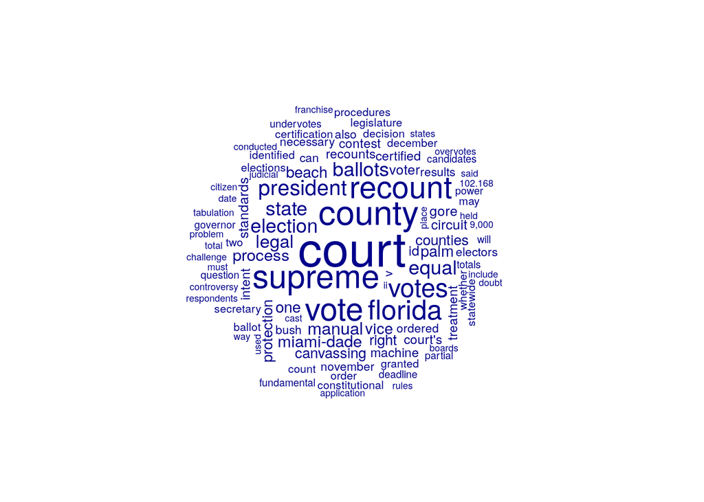

```r
textplot_wordcloud(opinion_dfm, max_words = 100)
```

#### Kenndy Word Cloud

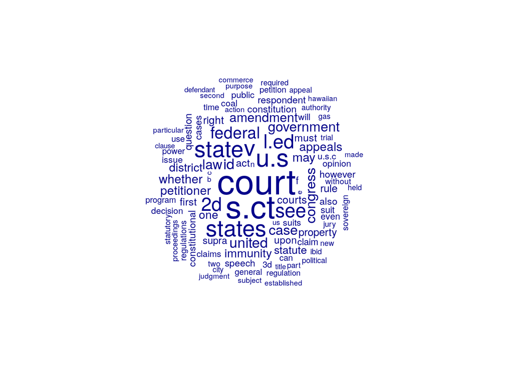

```r
textplot_wordcloud(kennedy_dfm, max_words = 100)
```

#### O’Connor Word Cloud

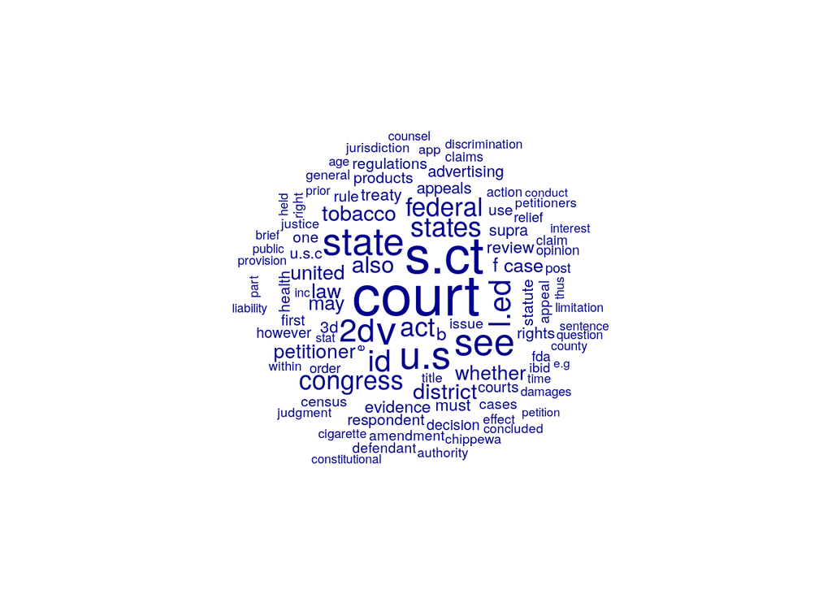

```r
textplot_wordcloud(oconnor_dfm, max_words = 100)
```

#### Rehnquist Word Cloud

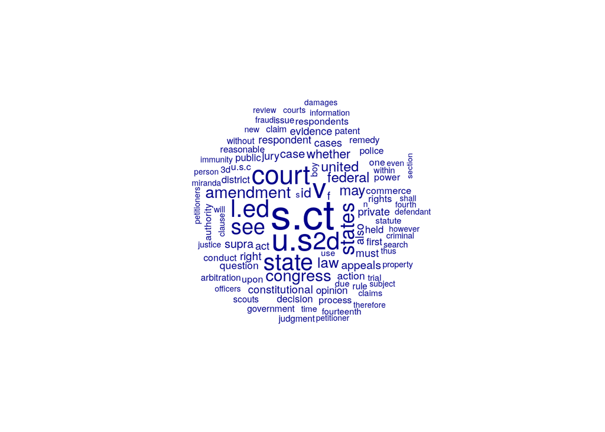

```r
textplot_wordcloud(rehnquist_dfm, max_words = 100)
```

#### Scalia Word Cloud

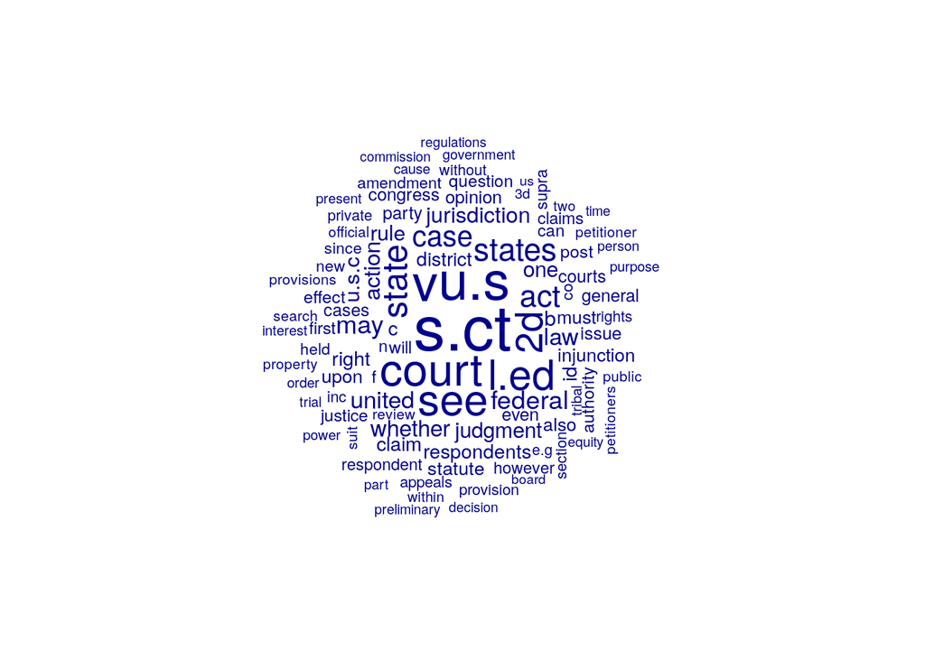

```r
textplot_wordcloud(scalia_dfm, max_words = 100)
```

#### Thomas Word Cloud

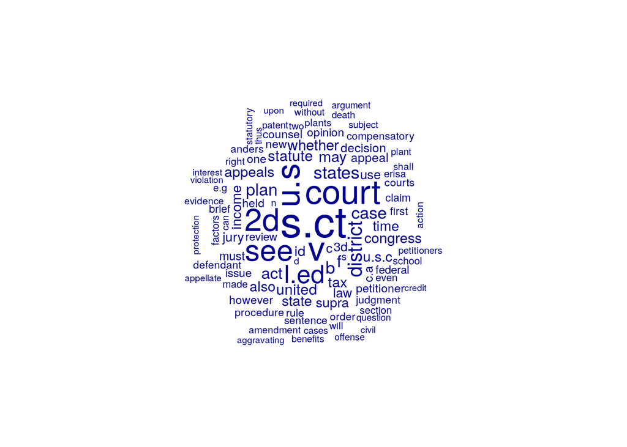

```r
textplot_wordcloud(thomas_dfm, max_words = 100)
```

### Lexical Diversity

`textstat_lexdiv()` calcuates lexical diversity in various measures based on the number of unique types of tokens and the length of a document. It is useful for analysing speakers or writers linguistic skill, or complexity of ideas expressed in documents.

```r
opinion_lexdiv <- textstat_lexdiv(opinion_dfm)
kennedy_lexdiv <- textstat_lexdiv(kennedy_dfm)
oconnor_lexdiv <- textstat_lexdiv(oconnor_dfm)
rehnquist_lexdiv <- textstat_lexdiv(rehnquist_dfm)
scalia_lexdiv <- textstat_lexdiv(scalia_dfm)
thomas_lexdiv <- textstat_lexdiv(thomas_dfm)

# head(opinion_lexdiv)
```

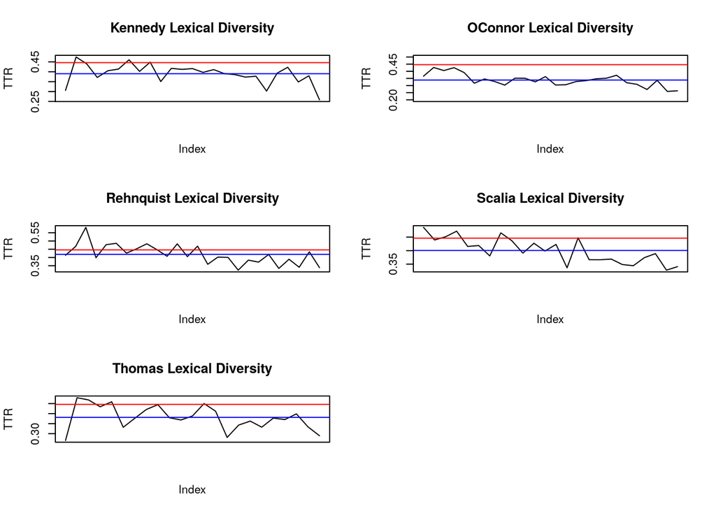

```r
par(mfrow=c(3, 2))
plot(kennedy_lexdiv$TTR, type = 'l', xaxt = 'n', xlab = NULL, ylab = "TTR",
     main = "Kennedy Lexical Diversity")
abline(h = opinion_lexdiv$TTR[1], col = "red")
abline(h = mean(kennedy_lexdiv$TTR), col = "blue")

plot(oconnor_lexdiv$TTR, type = 'l', xaxt = 'n', xlab = NULL, ylab = "TTR",
     ylim=c(0.2, 0.5), main = "OConnor Lexical Diversity")
abline(h = opinion_lexdiv$TTR[1], col = "red")
abline(h = mean(oconnor_lexdiv$TTR), col = "blue")

plot(rehnquist_lexdiv$TTR, type = 'l', xaxt = 'n', xlab = NULL, ylab = "TTR",
     main = "Rehnquist Lexical Diversity")
abline(h = opinion_lexdiv$TTR[1], col = "red")
abline(h = mean(rehnquist_lexdiv$TTR), col = "blue")

plot(scalia_lexdiv$TTR, type = 'l', xaxt = 'n', xlab = NULL, ylab = "TTR",
     main = "Scalia Lexical Diversity")
abline(h = opinion_lexdiv$TTR[1], col = "red")
abline(h = mean(scalia_lexdiv$TTR), col = "blue")

plot(thomas_lexdiv$TTR, type = 'l', xaxt = 'n', xlab = NULL, ylab = "TTR",
     main = "Thomas Lexical Diversity")
abline(h = opinion_lexdiv$TTR[1], col = "red")
abline(h = mean(thomas_lexdiv$TTR), col = "blue")
```

### Cluster Dendrogram

`textstat_dist()` calcuates similarites of documents or features for various measures. Its output is compatible with R’s `dist()`, so hierachical clustering can be perfromed without any transformation.

Below is a dendrogram of all of the documents from all conservative SC justices, including the Bush v. Gore opinion (can be located in the center).

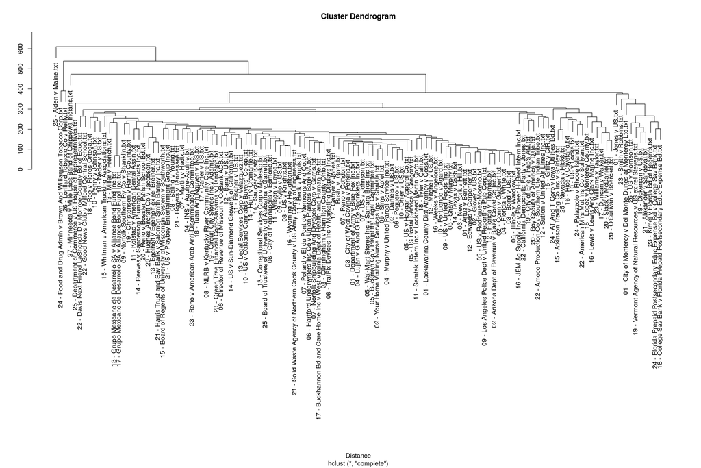

```r
# library(dendextend)
all_docs <- bind_rows(opinion, kennedy, oconnor, rehnquist, scalia, thomas)
all_docs <- corpus(all_docs)
all_docs_lower <- tolower(all_docs)
all_docs_toks <- tokens(all_docs_lower)
all_docs_nostop <- tokens_select(all_docs_toks, pattern = stopwords('en'),
                                selection = 'remove')
all_docs_cleaned <- tokens_remove(tokens(all_docs_nostop, remove_punct = TRUE,
                                  remove_numbers = TRUE), stopwords("english"))
all_docs_dfm <- dfm(all_docs_cleaned)
tstat_dist <- as.dist(textstat_dist(all_docs_dfm))
clust <- hclust(tstat_dist)
# clust <- as.dendrogram(clust)
plot(clust, xlab = "Distance", ylab = NULL, main = "Cluster Dendrogram")
```

```r
# labels_colors(clust) <- 1
```

### Selecting Keywords and Keyphrases

You can see how keywords are used in the actual contexts in a concordance view produced by `kwic()`

```r
opinion_kw <- kwic(opinion_corpus, pattern =  'vot*')
head(opinion_kw, 10)
```

```
#>
#>   [Bush_v_Gore.txt, 38]         the inclusion in the certified | vote  |
#>   [Bush_v_Gore.txt, 42]           certified vote totals of 215 | votes |
#>   [Bush_v_Gore.txt, 50]              Palm Beach County and 168 | votes |
#>  [Bush_v_Gore.txt, 103]              Palm Beach County was 176 | votes |
#>  [Bush_v_Gore.txt, 255] petitioner Bush had received 2,909,135 | votes |
#>  [Bush_v_Gore.txt, 263] respondent Gore had received 2,907,351 | votes |
#>  [Bush_v_Gore.txt, 292]                             ... of the | votes |
#>  [Bush_v_Gore.txt, 479]       winner of Florida's 25 electoral | votes |
#>  [Bush_v_Gore.txt, 534]                 of a number of illegal | votes |
#>  [Bush_v_Gore.txt, 542]                   of a number of legal | votes |
#>
#>  totals of 215 votes identified
#>  identified in Palm Beach County
#>  identified in Miami-Dade County for
#>  , and directed the Circuit
#>  , and respondent Gore had
#>  , a margin of 1,784
#>  cast," an automatic
#>  . On November 27,
#>  or rejection of a number
#>  sufficient to change or place
```

You can generate n-grams in any lengths from a tokens using `tokens_ngrams()`. N-grams are a sequence of tokens from already tokenized text objects.

```r
## where we left off with quanteda
## https://tutorials.quanteda.io/basic-operations/fcm/fcm/
# toks_ngram <- tokens_ngrams(toks, n = 2:4)
```